# Home Credit EDA

Joonas Tahvanainen

2024-09-29

# Loading the data

```r
library(tidyverse)
application_test <- read_csv("application_test.csv")
application_train <- read_csv("application_train.csv")
pos_cash <- read_csv("POS_CASH_balance.csv")
home_credit_columns_description <- read_csv("HomeCredit_columns_description.csv")
bureau <- read_csv("bureau.csv")
bureau_balance <- read_csv("bureau_balance.csv")
credt_card_balance <- read_csv("credit_card_balance.csv")
installment_payments <- read_csv("installments_payments.csv")
previous_applications <- read_csv("previous_application.csv")
```

# Packages

```r
library(tidyverse)
library(skimr)
library(summarytools)
```

# Exploring the target variable in application_{train|test}.csv

```r
#Using skimr to skim the dataset
skimmed<-skim(application_train)

# Getting the majority class classifier
skimmed %>%
  filter(skim_variable == "TARGET") %>%
  pull(numeric.mean)
```

```
## [1] 0.08072882
```

Based on the majority class classifier the probability of default is 8.07%. Based on that, the data is definitely unbalance as the defaults only make up a small portion of the overall data.

```r
# looking at the structure of the data frame
str(application_train)
```

# Data transformations

I’m assuming that transforming some of these character and flag variables will make the analysis slightly easier.

```r
# Converting every flag and character variable into a factor for easier analysis as well as the target variable
at_clean <- application_train %>%
  mutate(across(where(is.character), as.factor))

at_clean <- at_clean %>%
  mutate(across(matches("flag", ignore.case = TRUE), as.factor))

at_clean <- at_clean %>%
  mutate(across(c(REG_REGION_NOT_LIVE_REGION,
                  REG_REGION_NOT_WORK_REGION,
                  LIVE_REGION_NOT_WORK_REGION,
                  REG_CITY_NOT_LIVE_CITY,
                  REG_CITY_NOT_WORK_CITY,
                  LIVE_CITY_NOT_WORK_CITY,
                  TARGET), as.factor))

str(at_clean)
```

```r
library(janitor)

# Cleaning the data set a little more to make all column names lower case
at_clean <- at_clean %>% clean_names()
```

# Exploring variables

```r
# looking at the summaries of all numeric variables
summary(at_clean[sapply(at_clean, is.numeric)])
```

A lot of these living situation variables seem unnecessary and there’s a lot of NA’s. My goal is to try to find out if they’re really necessary, and hopefully remove them from the final data frame.

```r
# Most of the living situation variables seem to have a lot of missing values. I want to find out if we really need them.

# List of living situation variables
living_situation_vars <- c(
  "apartments_avg", "basementarea_avg", "years_beginexpluatation_avg",
  "years_build_avg", "commonarea_avg", "elevators_avg",
  "entrances_avg", "floorsmax_avg", "floorsmin_avg",
  "landarea_avg", "livingapartments_avg", "livingarea_avg",
  "nonlivingapartments_avg", "nonlivingarea_avg", "apartments_mode",
  "basementarea_mode", "years_beginexpluatation_mode", "years_build_mode",
  "commonarea_mode", "elevators_mode", "entrances_mode",
  "floorsmax_mode", "floorsmin_mode", "landarea_mode",
  "livingapartments_mode", "livingarea_mode", "nonlivingapartments_mode",
  "nonlivingarea_mode", "apartments_medi", "basementarea_medi",
  "years_beginexpluatation_medi", "years_build_medi", "commonarea_medi",
  "elevators_medi", "entrances_medi", "floorsmax_medi",
  "floorsmin_medi", "landarea_medi", "livingapartments_medi",
  "livingarea_medi", "nonlivingapartments_medi", "nonlivingarea_medi",  "totalarea_mode"
)


#Calculating summary statistics for the living variables
at_clean %>%
  group_by(target) %>%
  summarise(across(all_of(living_situation_vars),
                   list(mean = mean,
                        sd = sd,
                        median = median),
                   na.rm = TRUE))
```

```
## # A tibble: 2 × 130
##   target apartments_avg_mean apartments_avg_sd apartments_avg_median
##   <fct>                <dbl>             <dbl>                 <dbl>
## 1 0                    0.118             0.109                0.0887
## 2 1                    0.106             0.101                0.0825
## # ℹ 126 more variables: basementarea_avg_mean <dbl>, basementarea_avg_sd <dbl>,
## #   basementarea_avg_median <dbl>, years_beginexpluatation_avg_mean <dbl>,
## #   years_beginexpluatation_avg_sd <dbl>,
## #   years_beginexpluatation_avg_median <dbl>, years_build_avg_mean <dbl>,
## #   years_build_avg_sd <dbl>, years_build_avg_median <dbl>,
## #   commonarea_avg_mean <dbl>, commonarea_avg_sd <dbl>,
## #   commonarea_avg_median <dbl>, elevators_avg_mean <dbl>, …
```

Based on the summaries, my thought is that those variables might be useless for further analysis and prediction. We’ll do a simple linear model to explore more of the predictive power.

```r
# Based on the summary statistics, it's possible there's not much there. Let's run a simple linear model to see if there's any statistically significant predictive power in those variables

at_clean_lm <- at_clean %>%
  mutate(target = as.numeric(as.character(target)))

# Create the linear model
lm_model <- lm(target ~ ., data = at_clean_lm %>% select(target, all_of(living_situation_vars)))

# View the summary of the model
summary(lm_model)
```

```
##
## Call:
## lm(formula = target ~ ., data = at_clean_lm %>% select(target,
##     all_of(living_situation_vars)))
##
## Residuals:
##      Min       1Q   Median       3Q      Max
## -0.21904 -0.07735 -0.07095 -0.05955  1.05248
##
## Coefficients:
##                               Estimate Std. Error t value Pr(>|t|)
## (Intercept)                   0.025255   0.135983   0.186   0.8527
## apartments_avg                0.077156   0.113262   0.681   0.4957
## basementarea_avg             -0.132758   0.094326  -1.407   0.1593
## years_beginexpluatation_avg   0.421257   0.463106   0.910   0.3630
## years_build_avg               0.165106   0.144859   1.140   0.2544
## commonarea_avg                0.056989   0.129157   0.441   0.6590
## elevators_avg                -0.050281   0.088222  -0.570   0.5687
## entrances_avg                -0.086293   0.125413  -0.688   0.4914
## floorsmax_avg                -0.041597   0.091058  -0.457   0.6478
## floorsmin_avg                -0.061222   0.080647  -0.759   0.4478
## landarea_avg                  0.063720   0.072048   0.884   0.3765
## livingapartments_avg         -0.101947   0.128085  -0.796   0.4261
## livingarea_avg               -0.030643   0.099995  -0.306   0.7593
## nonlivingapartments_avg      -0.047263   0.204538  -0.231   0.8173
## nonlivingarea_avg            -0.020689   0.084387  -0.245   0.8063
## apartments_mode               0.022541   0.067989   0.332   0.7402
## basementarea_mode             0.082834   0.061178   1.354   0.1757
## years_beginexpluatation_mode -0.093013   0.154150  -0.603   0.5463
## years_build_mode             -0.037177   0.060044  -0.619   0.5358
## commonarea_mode               0.083410   0.068347   1.220   0.2223
## elevators_mode                0.022839   0.053305   0.428   0.6683
## entrances_mode                0.002624   0.057676   0.045   0.9637
## floorsmax_mode                0.021936   0.046032   0.477   0.6337
## floorsmin_mode               -0.013317   0.042747  -0.312   0.7554
## landarea_mode                -0.030186   0.060929  -0.495   0.6203
## livingapartments_mode        -0.064108   0.065633  -0.977   0.3287
## livingarea_mode              -0.013066   0.054732  -0.239   0.8113
## nonlivingapartments_mode      0.167573   0.094086   1.781   0.0749 .
## nonlivingarea_mode           -0.068933   0.061322  -1.124   0.2610
## apartments_medi              -0.068967   0.120193  -0.574   0.5661
## basementarea_medi             0.057290   0.104407   0.549   0.5832
## years_beginexpluatation_medi -0.242453   0.215230  -1.126   0.2600
## years_build_medi             -0.145864   0.143796  -1.014   0.3104
## commonarea_medi              -0.127589   0.137752  -0.926   0.3543
## elevators_medi               -0.024471   0.099811  -0.245   0.8063
## entrances_medi               -0.007196   0.132419  -0.054   0.9567
## floorsmax_medi               -0.059773   0.096890  -0.617   0.5373
## floorsmin_medi                0.065407   0.088192   0.742   0.4583
## landarea_medi                -0.022042   0.090309  -0.244   0.8072
## livingapartments_medi         0.206496   0.132836   1.555   0.1201
## livingarea_medi               0.049538   0.103274   0.480   0.6315
## nonlivingapartments_medi     -0.092328   0.220494  -0.419   0.6754
## nonlivingarea_medi            0.059294   0.099740   0.594   0.5522
## totalarea_mode                0.037176   0.023009   1.616   0.1062
## ---
## Signif. codes:  0 '***' 0.001 '**' 0.01 '*' 0.05 '.' 0.1 ' ' 1
##
## Residual standard error: 0.2541 on 81508 degrees of freedom
##   (225959 observations deleted due to missingness)
## Multiple R-squared:  0.002859,   Adjusted R-squared:  0.002333
## F-statistic: 5.435 on 43 and 81508 DF,  p-value: < 2.2e-16
```

None of the variables representing the living situation of the applicant seem to be statistically significant in the linear model. We will remove all those variables that tell us something about the applicant’s living situation.

```r
# Based on what we saw, we're going to remove all living situation variables from the dataset:
at_clean <- at_clean %>%
  select(-all_of(living_situation_vars),
         -fondkapremont_mode,
         -housetype_mode,
         -wallsmaterial_mode,
         -emergencystate_mode)
```

Let’s look at the data after removing those variables.

```r
# Now we can get into exploring some of the relationships between the variables. For now, I'll just look at the means of each numeric variable across the levels of the target
skim(at_clean)
```

```r
summary(at_clean)
```

Out of the summary, days_employed stands out with very high max values. Let’s see if we can do something about it.

```r
# pulling rows where days employed is positive to see what's going on
at_clean %>%
  filter(days_employed > 0) %>%
  head(10)
```

```
## # A tibble: 10 × 75
##    sk_id_curr target name_contract_type code_gender flag_own_car flag_own_realty
##         <dbl> <fct>  <fct>              <fct>       <fct>        <fct>
##  1     100011 0      Cash loans         F           N            Y
##  2     100015 0      Cash loans         F           N            Y
##  3     100027 0      Cash loans         F           N            Y
##  4     100045 0      Cash loans         F           N            Y
##  5     100050 0      Cash loans         F           N            Y
##  6     100053 0      Cash loans         F           N            Y
##  7     100062 0      Cash loans         M           Y            N
##  8     100064 0      Cash loans         F           N            N
##  9     100073 0      Cash loans         M           Y            Y
## 10     100094 0      Cash loans         F           N            Y
## # ℹ 69 more variables: cnt_children <dbl>, amt_income_total <dbl>,
## #   amt_credit <dbl>, amt_annuity <dbl>, amt_goods_price <dbl>,
## #   name_type_suite <fct>, name_income_type <fct>, name_education_type <fct>,
## #   name_family_status <fct>, name_housing_type <fct>,
## #   region_population_relative <dbl>, days_birth <dbl>, days_employed <dbl>,
## #   days_registration <dbl>, days_id_publish <dbl>, own_car_age <dbl>,
## #   flag_mobil <fct>, flag_emp_phone <fct>, flag_work_phone <fct>, …
```

```r
# looks like if days_employed is positive, it means that they are not currently working. the occupation is n/a and income type is not employment either.
# let's convert all those positive values into 0, and negative values into positive for clarity
at_clean <- at_clean %>%
  mutate(days_employed = ifelse(days_employed > 0, 0, days_employed))

at_clean <- at_clean %>%
  mutate(days_employed = abs(days_employed))

# making sure days_employed is now cleaned
at_clean %>%
  summarise(
    mean_days_employed = mean(days_employed, na.rm = TRUE),
    min_days_employed = min(days_employed, na.rm = TRUE),
    max_days_employed = max(days_employed, na.rm = TRUE)
  )
```

```
## # A tibble: 1 × 3
##   mean_days_employed min_days_employed max_days_employed
##                <dbl>             <dbl>             <dbl>
## 1              1955.                 0             17912
```

Also, looks like some of the occupation types might be missing. Let’s see what’s going on there.

```r
# Looking at why some occupation types might be missing
at_clean %>%
  filter(is.na(occupation_type)) %>%
  sample_n(10)

# Looks like some may have just forgotten to put it in or something similar. We'll define unemployed and not listed based on days_employed
at_clean <- at_clean %>%
  mutate(occupation_type = case_when(
    is.na(occupation_type) & days_employed > 0 ~ 'Not listed',
    is.na(occupation_type) & days_employed == 0 ~ 'Unemployed',
    TRUE ~ occupation_type  # Keep original value if not NA
  )) %>% mutate(occupation_type = factor(occupation_type))

skim(at_clean)
```

name_type_suite is the last categorical variable that has missing values. since there’s only 1292, we’ll remove all those rows

```r
# name_type_suite is the last categorical variable that has missing values. since there's only 1292, we'll remove all those rows
at_clean <- at_clean %>%
  filter(!is.na(name_type_suite))
```

# Exploring and cleaning up numeric variables

```r
# now that the categorical variables are clean, we'll look at the numeric ones
summary(at_clean[sapply(at_clean, is.numeric)])
```

The credit scores, AKA ext_sources need to be cleaned up somehow:

```r
# let's tackle the credit score issue first.

# first, I'm assuming all ext_sources stand for a credit bureau (experian, transunion, equifax). We're going to calculate the average score for each applicant.
# if ext_sources are all n/a then the score will be 0
at_clean <- at_clean %>%
  mutate(avg_credit_score = rowMeans(
    select(., ext_source_1, ext_source_2, ext_source_3),
    na.rm = TRUE
  )) %>%
  mutate(avg_credit_score = ifelse(is.na(avg_credit_score), 0, avg_credit_score))

# next we'll create flags for each credit scenario and also remove the old ext_sources
at_clean <- at_clean %>%
  mutate(
    limited_credit_flag = case_when(
      rowSums(!is.na(select(., ext_source_1, ext_source_2, ext_source_3))) %in% 1:2 ~ 1,
      TRUE ~ 0
    ),
    no_credit_flag = case_when(
      rowSums(is.na(select(., ext_source_1, ext_source_2, ext_source_3))) == 3 ~ 1,
      TRUE ~ 0
    ),
    full_credit_flag = case_when(
      rowSums(!is.na(select(., ext_source_1, ext_source_2, ext_source_3))) == 3 ~ 1,
      TRUE ~ 0
    )
  ) %>%
  mutate(
    limited_credit_flag = factor(limited_credit_flag),
    no_credit_flag = factor(no_credit_flag),
    full_credit_flag = factor(full_credit_flag)
  ) %>%
  select(-ext_source_1, -ext_source_2, -ext_source_3)


# take a loo
skim(at_clean)
```

Here we created an average credit score for each customer, and also put them into buckets (Created flags) based on their credit profile or whether they have scores or no.

Next, we’ll take a look at how the variables representing car ownership affect the dependent variable using some simple linear regression and boxplots

```r
# running two very simple lm models to look at the relationship between the car ownership variables
lm(as.numeric(target) ~ flag_own_car, data = at_clean) %>% summary()
```

```
##
## Call:
## lm(formula = as.numeric(target) ~ flag_own_car, data = at_clean)
##
## Residuals:
##      Min       1Q   Median       3Q      Max
## -0.08510 -0.08510 -0.08510 -0.07257  0.92743
##
## Coefficients:
##                 Estimate Std. Error t value Pr(>|t|)
## (Intercept)    1.0851044  0.0006063 1789.73   <2e-16 ***
## flag_own_carY -0.0125328  0.0010395  -12.06   <2e-16 ***
## ---
## Signif. codes:  0 '***' 0.001 '**' 0.01 '*' 0.05 '.' 0.1 ' ' 1
##
## Residual standard error: 0.2725 on 306217 degrees of freedom
## Multiple R-squared:  0.0004745,  Adjusted R-squared:  0.0004712
## F-statistic: 145.4 on 1 and 306217 DF,  p-value: < 2.2e-16
```

```r
lm(as.numeric(target) ~ own_car_age, data = at_clean) %>% summary()
```

```
##
## Call:
## lm(formula = as.numeric(target) ~ own_car_age, data = at_clean)
##
## Residuals:
##      Min       1Q   Median       3Q      Max
## -0.13699 -0.07415 -0.06925 -0.06598  0.93728
##
## Coefficients:
##              Estimate Std. Error t value Pr(>|t|)
## (Intercept) 1.0627193  0.0011417  930.82   <2e-16 ***
## own_car_age 0.0008162  0.0000672   12.14   <2e-16 ***
## ---
## Signif. codes:  0 '***' 0.001 '**' 0.01 '*' 0.05 '.' 0.1 ' ' 1
##
## Residual standard error: 0.2593 on 104169 degrees of freedom
##   (202048 observations deleted due to missingness)
## Multiple R-squared:  0.001414,   Adjusted R-squared:  0.001404
## F-statistic: 147.5 on 1 and 104169 DF,  p-value: < 2.2e-16
```

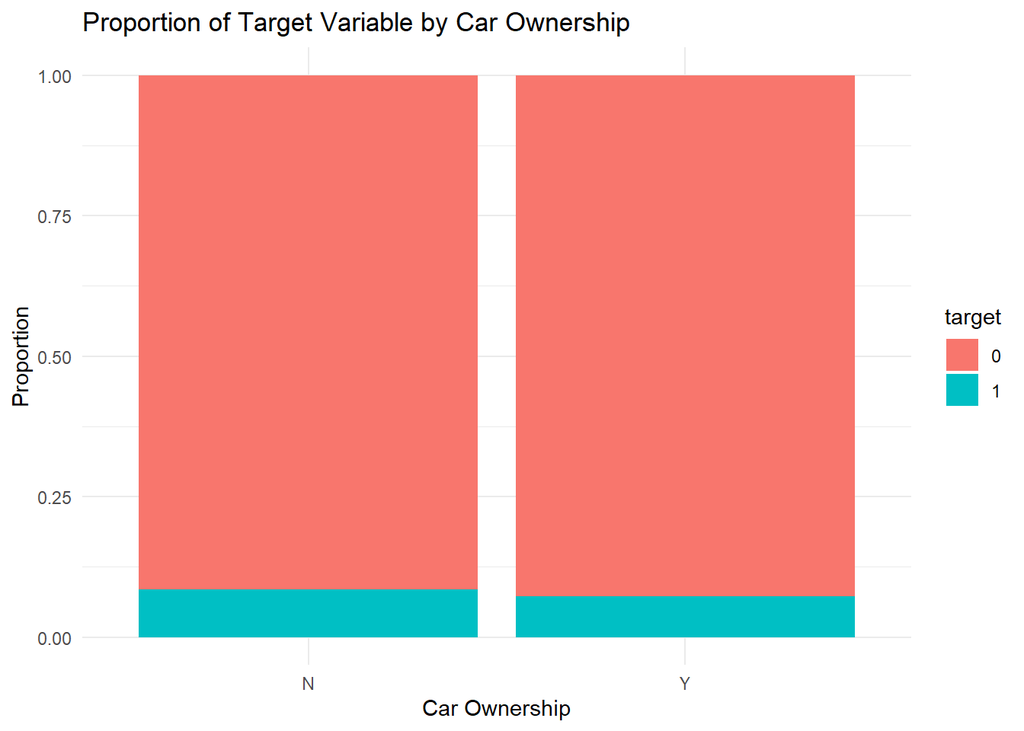

```r
# visualizing some of the relationship
ggplot(at_clean, aes(x = flag_own_car, fill = target)) +
  geom_bar(position = "fill") +  # Position fill gives proportions
  labs(title = "Proportion of Target Variable by Car Ownership",
       x = "Car Ownership",
       y = "Proportion") +
  theme_minimal()
```

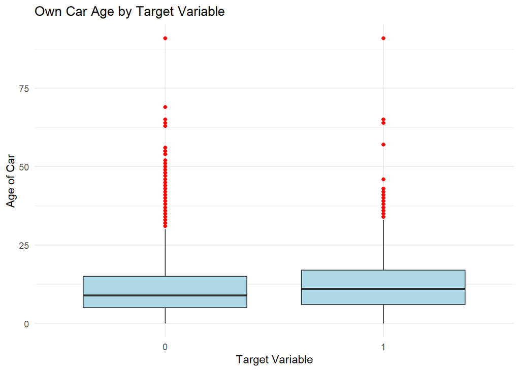

```r
ggplot(at_clean %>% filter(flag_own_car == "Y"), aes(x = as.factor(target), y = own_car_age)) +
  geom_boxplot(fill = "lightblue", outlier.color = "red") +
  labs(title = "Own Car Age by Target Variable",
       x = "Target Variable",
       y = "Age of Car") +
  theme_minimal()
```

Based on the results, it’s possible that car ownership and the age of the car have an effect on the target variable.

```r
# Based on the above analysis, it's possible the car variables will be important for modeling so we'll keep them for now, We'lll change the car age variable into a factor
at_clean <- at_clean %>%
  mutate(own_car_age = case_when(
    is.na(own_car_age) ~ 'No car',
    own_car_age >= 10 ~ '10+ years',
    own_car_age < 10 ~ 'Less than 10 years'
  )) %>%
  mutate(own_car_age = as.factor(own_car_age))

skim(at_clean)
```

There’s 6 variables representing bureau inquiries. There are total of 41410 missing values, likely because they didn’t have a specific credit report available. We’ll see if it’s possible to just convert those NA values to 0’s.

```r
# let's see what's going on with the n/a bureau inquiries
at_clean %>%
  filter(is.na(amt_req_credit_bureau_day))

# seeing if they're related with the credit_flags
at_clean %>%
  filter(is.na(amt_req_credit_bureau_day)) %>%
  summarise(
    mean_limited_credit_flag = mean(as.numeric(as.character(limited_credit_flag)), na.rm = TRUE),
    mean_no_credit_flag = mean(as.numeric(as.character(no_credit_flag)), na.rm = TRUE),
    mean_full_credit_flag = mean(as.numeric(as.character(full_credit_flag)), na.rm = TRUE)
  )

# looks like the bureau inquiries are related with an applicant not having a credit score, probably meaning that the credit report is missing. We'll convert the missing values to zeros
# since it means that they have never inquired for credit before
at_clean <- at_clean %>%
  mutate(
    amt_req_credit_bureau_hour = replace_na(amt_req_credit_bureau_hour, 0),
    amt_req_credit_bureau_day = replace_na(amt_req_credit_bureau_day, 0),
    amt_req_credit_bureau_week = replace_na(amt_req_credit_bureau_week, 0),
    amt_req_credit_bureau_mon = replace_na(amt_req_credit_bureau_mon, 0),
    amt_req_credit_bureau_qrt = replace_na(amt_req_credit_bureau_qrt, 0),
    amt_req_credit_bureau_year = replace_na(amt_req_credit_bureau_year, 0)
  )


skim(at_clean)
```

Cleaning up missing values for the observation variables.

```r
# the observation variables only have 1021 missing values, the annuity column has 12 missing values, and the phone column has 1 missing value. let's just get rid of those rows
at_clean <- at_clean %>%
  filter(
    !is.na(amt_annuity) &
    !is.na(obs_30_cnt_social_circle) &
    !is.na(def_30_cnt_social_circle) &
    !is.na(obs_60_cnt_social_circle) &
    !is.na(def_60_cnt_social_circle) &
    !is.na(days_last_phone_change)
  )

skim(at_clean)
```

```r
#now we have a dataset that is somewhat cleaned with no missing values. let's look at what else we can find

summary(at_clean)
str(at_clean)
```

# Aggregating and joining the bureau data frame to the cleaned application train

```r
# cleaning up
bureau <- clean_names(bureau)
bureau$credit_active <- as.factor(bureau$credit_active)
bureau$credit_type <- as.factor(bureau$credit_type)
bureau <- clean_names(bureau)

# taking a glance at the summary
summary(bureau)
```

```
##    sk_id_curr      sk_id_bureau      credit_active     credit_currency
##  Min.   :100001   Min.   :5000000   Active  : 630607   Length:1716428
##  1st Qu.:188867   1st Qu.:5463954   Bad debt:     21   Class :character
##  Median :278055   Median :5926304   Closed  :1079273   Mode  :character
##  Mean   :278215   Mean   :5924434   Sold    :   6527
##  3rd Qu.:367426   3rd Qu.:6385681
##  Max.   :456255   Max.   :6843457
##
##   days_credit    credit_day_overdue  days_credit_enddate days_enddate_fact
##  Min.   :-2922   Min.   :   0.0000   Min.   :-42060.0    Min.   :-42023
##  1st Qu.:-1666   1st Qu.:   0.0000   1st Qu.: -1138.0    1st Qu.: -1489
##  Median : -987   Median :   0.0000   Median :  -330.0    Median :  -897
##  Mean   :-1142   Mean   :   0.8182   Mean   :   510.5    Mean   : -1017
##  3rd Qu.: -474   3rd Qu.:   0.0000   3rd Qu.:   474.0    3rd Qu.:  -425
##  Max.   :    0   Max.   :2792.0000   Max.   : 31199.0    Max.   :     0
##                                      NA's   :105553      NA's   :633653
##  amt_credit_max_overdue cnt_credit_prolong amt_credit_sum
##  Min.   :        0      Min.   :0.00000    Min.   :        0
##  1st Qu.:        0      1st Qu.:0.00000    1st Qu.:    51300
##  Median :        0      Median :0.00000    Median :   125518
##  Mean   :     3825      Mean   :0.00641    Mean   :   354995
##  3rd Qu.:        0      3rd Qu.:0.00000    3rd Qu.:   315000
##  Max.   :115987185      Max.   :9.00000    Max.   :585000000
##  NA's   :1124488                           NA's   :13
##  amt_credit_sum_debt amt_credit_sum_limit amt_credit_sum_overdue
##  Min.   : -4705600   Min.   :-586406      Min.   :      0
##  1st Qu.:        0   1st Qu.:      0      1st Qu.:      0
##  Median :        0   Median :      0      Median :      0
##  Mean   :   137085   Mean   :   6230      Mean   :     38
##  3rd Qu.:    40154   3rd Qu.:      0      3rd Qu.:      0
##  Max.   :170100000   Max.   :4705600      Max.   :3756681
##  NA's   :257669      NA's   :591780
##                         credit_type      days_credit_update  amt_annuity
##  Consumer credit              :1251615   Min.   :-41947.0   Min.   :        0
##  Credit card                  : 402195   1st Qu.:  -908.0   1st Qu.:        0
##  Car loan                     :  27690   Median :  -395.0   Median :        0
##  Mortgage                     :  18391   Mean   :  -593.8   Mean   :    15713
##  Microloan                    :  12413   3rd Qu.:   -33.0   3rd Qu.:    13500
##  Loan for business development:   1975   Max.   :   372.0   Max.   :118453424
##  (Other)                      :   2149                      NA's   :1226791
```

```r
# what are the different credit types in the data set
bureau %>% distinct(credit_type)
```

```
## # A tibble: 15 × 1
##    credit_type
##    <fct>
##  1 Consumer credit
##  2 Credit card
##  3 Mortgage
##  4 Car loan
##  5 Microloan
##  6 Loan for working capital replenishment
##  7 Loan for business development
##  8 Real estate loan
##  9 Unknown type of loan
## 10 Another type of loan
## 11 Cash loan (non-earmarked)
## 12 Loan for the purchase of equipment
## 13 Mobile operator loan
## 14 Interbank credit
## 15 Loan for purchase of shares (margin lending)
```

For the aggregation this time we’ll keep this very simple. Once we get to the actual modelling, we could possibly create 10’s or even 100’s credit variables.

```r
# creating 4 aggregated variables
bureau_agg <- bureau %>%
  group_by(sk_id_curr) %>%
  summarise(
    total_past_due = sum(amt_credit_sum_overdue, na.rm = TRUE),  # Sum of past due amounts
    number_of_accounts = n(),  # Count of rows per sk_id_curr
    number_of_paid_accounts = sum(credit_active == 'Closed' & (is.na(amt_credit_sum_debt) | amt_credit_sum_debt == 0)),  # Count of paid off accounts
    ct_mortgage_auto = sum(credit_type %in% c('Car loan', 'Mortgage', 'Real estate loan'))  # Count of mortgage and auto-related credit types
  )
```

Joining the aggreagated bureau data to at_clean

```r
# join the data
at_join <- at_clean %>%
  left_join(bureau_agg, by = "sk_id_curr")


# converting NA's to 0's
at_join <- at_join %>%
  mutate(
    total_past_due = replace_na(total_past_due, 0),
    number_of_accounts = replace_na(number_of_accounts, 0),
    number_of_paid_accounts = replace_na(number_of_paid_accounts, 0),
    ct_mortgage_auto = replace_na(ct_mortgage_auto, 0)
  )
```

Looking at how the new credit variables may affect the target variable

```r
# running a linear regression to look at the relationships, therefore target needs to go back to numeric
at_join$target <- as.numeric(as.character(at_join$target))

lm(target ~ total_past_due + number_of_accounts + number_of_paid_accounts + ct_mortgage_auto,
                   data = at_join) %>% summary()
```

```
##
## Call:
## lm(formula = target ~ total_past_due + number_of_accounts + number_of_paid_accounts +
##     ct_mortgage_auto, data = at_join)
##
## Residuals:
##      Min       1Q   Median       3Q      Max
## -0.99350 -0.09109 -0.07928 -0.06406  1.11291
##
## Coefficients:
##                           Estimate Std. Error t value Pr(>|t|)
## (Intercept)              7.928e-02  7.309e-04 108.476  < 2e-16 ***
## total_past_due           2.545e-07  3.582e-08   7.104 1.21e-12 ***
## number_of_accounts       1.181e-02  3.004e-04  39.316  < 2e-16 ***
## number_of_paid_accounts -1.754e-02  4.042e-04 -43.392  < 2e-16 ***
## ct_mortgage_auto        -2.131e-02  1.208e-03 -17.646  < 2e-16 ***
## ---
## Signif. codes:  0 '***' 0.001 '**' 0.01 '*' 0.05 '.' 0.1 ' ' 1
##
## Residual standard error: 0.2718 on 305180 degrees of freedom
## Multiple R-squared:  0.007282,   Adjusted R-squared:  0.007269
## F-statistic: 559.6 on 4 and 305180 DF,  p-value: < 2.2e-16
```

```r
# creating a table to look at how the credit variables are distributed
at_table <- at_join %>%
  group_by(target) %>%
  summarise(
    mean_total_past_due = mean(total_past_due, na.rm = TRUE),
    mean_number_of_accounts = mean(number_of_accounts, na.rm = TRUE),
    mean_paid_accounts = mean(number_of_paid_accounts, na.rm = TRUE),
    mean_ct_mortgage_auto = mean(ct_mortgage_auto, na.rm = TRUE)
  )

at_table
```

```
## # A tibble: 2 × 5
##   target mean_total_past_due mean_number_of_accounts mean_paid_accounts
##    <dbl>               <dbl>                   <dbl>              <dbl>
## 1      0                125.                    4.78               3.00
## 2      1                809.                    4.61               2.54
## # ℹ 1 more variable: mean_ct_mortgage_auto <dbl>
```

As seen in the linear regression model and the table, having a higher amount of past due credit could play a big role in predicting default and having paid accounts and mortgage and auto history could positively impact loan preformance.

# More simple analysis of different variables

```r
# seeing if income has effect
at_join %>%
  group_by(target) %>%
  summarise(avg_income = mean(amt_income_total, na.rm = TRUE))
```

```
## # A tibble: 2 × 2
##   target avg_income
##    <dbl>      <dbl>
## 1      0    168873.
## 2      1    165674.
```

```r
# looking at education type and if the probability of default is higher for some groups
at_join %>%
  group_by(name_education_type) %>%
  summarise(probability_default = mean(as.numeric(target), na.rm = TRUE))
```

```
## # A tibble: 5 × 2
##   name_education_type           probability_default
##   <fct>                                       <dbl>
## 1 Academic degree                            0.0184
## 2 Higher education                           0.0539
## 3 Incomplete higher                          0.0850
## 4 Lower secondary                            0.109
## 5 Secondary / secondary special              0.0896
```

```r
# length of employment
at_join %>%
  group_by(target) %>%
  summarise(
    mean_days_employed = mean(days_employed, na.rm = TRUE),
    median_days_employed = median(days_employed, na.rm = TRUE),
    sd_days_employed = sd(days_employed, na.rm = TRUE),
    count = n()
  )
```

```
## # A tibble: 2 × 5
##   target mean_days_employed median_days_employed sd_days_employed  count
##    <dbl>              <dbl>                <dbl>            <dbl>  <int>
## 1      0              1987.                 1235            2343. 280466
## 2      1              1597.                 1035            1833.  24719
```

```r
# credit scores
at_join %>%
  group_by(target) %>%
  summarise(
    mean_avg_credit_score = mean(avg_credit_score, na.rm = TRUE),
    median_avg_credit_score = median(avg_credit_score, na.rm = TRUE),
    sd_avg_credit_score = sd(avg_credit_score, na.rm = TRUE),
    count = n()
  )
```

```
## # A tibble: 2 × 5
##   target mean_avg_credit_score median_avg_credit_sc…¹ sd_avg_credit_score  count
##    <dbl>                 <dbl>                  <dbl>               <dbl>  <int>
## 1      0                 0.519                  0.534               0.145 280466
## 2      1                 0.397                  0.399               0.160  24719
## # ℹ abbreviated name: ¹median_avg_credit_score
```

```r
# credit profile
at_join %>%
  group_by(full_credit_flag) %>%
  summarise(
    probability_of_default = mean(as.numeric(target), na.rm = TRUE),
    count = n()
  )
```

```
## # A tibble: 2 × 3
##   full_credit_flag probability_of_default  count
##   <fct>                             <dbl>  <int>
## 1 0                                0.0853 196428
## 2 1                                0.0733 108757
```

# Summary of findings

To summarize, this EDA really just touched the surface. On an individual level there are definitely some variables that seem like they could have an effect on he target variable, such as education type, credit scores, length of employment, and also the applicant’s credit profile. Based on my experience (I work for a for subprime auto lender that has a highly complex risk model that uses 1000’s of credit variables) the credit variables need to be explored more.

In the main data there seemed to be some variables that are more unnecessary than useful, and even after the cleaning I did here, there might me some more that needs to be done.

I also haven’t fully determined how to go about the target variable ‘target’. The goal of the project is to be able to predict loan default so it might make sense to keep the target variable as a binary ‘yes/no’ variable, but I also like the idea of keeping it numeric to predict the probability of default. For the business perspective, if the model was to calculate the probability of default, it would give them more options as they could treat different probabilities of default differently (such as charge higher fees, rates, etc.) vs. if the model was only predicting yes/no, then every ‘no’ would be an automatic turn down.

There’s many considerations here. I can’t really grasp my head around the exact approach until we get to some modelling and testing. Based on the complexity of the data though, I would think that some sort of gradient boosting, neural network, or random forest type of model will be suitable for this project.